### WGU D212 Data Mining II

# Task 1 - Clustering Techniques

#### August 24, 2023

# Environment

- Python: 3.9.9
- Jupyter: 7.0.2

# Part I - Research Question

## A1. Propose one relevant question and choose a clustering technique.

### *What are the different groups within the organization's customer base?*

We will endeavor to answer the above question by using the K-means method.

## A2. Define one goal of the data analysis.

The ultimate goal of this data analysis is to reduce operating costs by increasing the efficiency of the organization's marketing efforts. We will use the K-means clustering technique identify the different groups within the organization's customer base and segment them accordingly. The organization will benefit from knowing the similarities and differences between customer groups because the knowledge will greatly influence how marketing is conducted. This will inform the decisions of stakeholders in matters where customer retention is involved, for example. Knowing which group a particular customer belong in will provide the organization with advanced insight towards that customer's characteristics or behavior. Thereby increasing the effective of marketing campaigns.

This goal is within the scope of the scenario and is represented in the available data.

# Part II - Method Justification

## B1. Explain how the clustering technique you chose analyzes the selected dataset. Include expected outcomes.

I chose K-means it's relatively easy to implement, scales to large data sets, and guarantees convergence. (Google.com, 2023). K-means works by taking data points as input and groups them into groups or k number of clusters.It starts the training process of grouping by selecting a number of starting center points called centroids. The algorithm then takes each data point and assigns them to the nearest centroid. Based on the new assignments, the centroids are then recalculated and the whole process repeats until they converge.

I expect the model to show the groupings of k number of clusters that are similar to each other (the data points are similar, not necessarily the clusters themselves.) I also expect a summary of the model's performance, such as silhoutte score.

## B2. Summarize one assumption of the chosen clustering technique.

One core assumption of K-means is that the "scales of different variables are specified so they can be reasonably combined using sum-of-squares as the measure to be minimised" (Henry, 2022). In other words, using K-means assumes that the radius of each cluster is the same.

## B3. List the packages or libraries you have chosen for Python or R, and justify how each item on the list supports the analysis.

The packages/libraries I've chosen are:

- sys: for running the executable file (d209_task1.py)
- random: set random seed for reproducibility of the experiment
- pandas: for manipulating dataframes
- numpy: for performing mathematical computations
- matplotlib and seaborn: for visualizations
- Image: display image from a URL
- StandardScaler: to scale the data set
- kmeans: clustering algorithm
- silhoutte_score: evaluating the model

# Part III - Data Preparation

## C1. Describe one data preprocessing goal relevant to the clustering technique from part A1.

One preprocessing goal is to standardize the variables to satisfy the spherical assumption of k-means. We will accomplish this using StandardScaler.

## C2. Identify the initial data set variables that you will use to analyze the classification question from part A1, and classify each variable as continuous or categorical.

Independent Variables:

- Children, Continuous, Quantitative
- Age, Continuous, Quantitative
- Income, Continuous, Quantitative
- Tenure, Continuous, Quantitative
- MonthlyCharge, Continuous, Quantitative
- Bandwidth_GB_Year, Continuous, Quantitative

## C3. Explain each of the steps used to prepare the data for the analysis. Identify the code segment for each step.

- Load and view the data

  > use pandas to read the csv use head or tail methods use info()
- Remove irrelevant data for the analysis

  > use the drop method
- Perform data cleaning

  > remove duplicates, missing values, outliers
- Pre-process data

  > scale the features
- Perform K-means clustering

  > determine optimal number of k clusters select best model get characteristics evaluate model

```python
# setting the random seed for reproducibility
import random
random.seed(493)

# for manipulating dataframes
import pandas as pd
import numpy as np

# for visualizations
%matplotlib inline
import matplotlib.pyplot as plt
import seaborn as sns
sns.set(style="whitegrid")
from IPython.display import Image

# for modeling
from sklearn.preprocessing import StandardScaler
from sklearn.cluster import KMeans
from sklearn.metrics import silhouette_score

# to print out all the outputs of the cell
from IPython.core.interactiveshell import InteractiveShell
InteractiveShell.ast_node_interactivity = "all"

# set display options
import warnings
warnings.filterwarnings('ignore')
pd.set_option('display.max_columns', None)
pd.set_option('display.max_rows', None)
pd.set_option('display.max_colwidth', None)
```

```python
# read the csv file
df = pd.read_csv('churn_clean.csv')
df.info()
df.head()
```

```
<class 'pandas.core.frame.DataFrame'>
RangeIndex: 10000 entries, 0 to 9999
Data columns (total 50 columns):
 #   Column                Non-Null Count  Dtype
---  ------                --------------  -----
 0   CaseOrder             10000 non-null  int64
 1   Customer_id           10000 non-null  object
 2   Interaction           10000 non-null  object
 3   UID                   10000 non-null  object
 4   City                  10000 non-null  object
 5   State                 10000 non-null  object
 6   County                10000 non-null  object
 7   Zip                   10000 non-null  int64
 8   Lat                   10000 non-null  float64
 9   Lng                   10000 non-null  float64
```

[output cut: 42 more lines]

|  | CaseOrder | Customer_id | Interaction | UID | City | State | County | Zip | Lat | Lng | Population | Area | TimeZone | Job | Children | Age | Income | Marital | Gender | Churn | Outage_sec_perweek | Email | Contacts | Yearly_equip_failure | Techie | Contract | Port_modem | Tablet | InternetService | … |
| --- | --- | --- | --- | --- | --- | --- | --- | --- | --- | --- | --- | --- | --- | --- | --- | --- | --- | --- | --- | --- | --- | --- | --- | --- | --- | --- | --- | --- | --- | --- |
| 0 | 1 | K409198 | aa90260b-4141-4a24-8e36-b04ce1f4f77b | e885b299883d4f9fb18e39c75155d990 | Point Baker | AK | Prince of Wales-Hyder | 99927 | 56.25100 | -133.37571 | 38 | Urban | America/Sitka | Environmental health practitioner | 0 | 68 | 28561.99 | Widowed | Male | No | 7.978323 | 10 | 0 | 1 | No | One year | Yes | Yes | Fiber Optic | … |
| 1 | 2 | S120509 | fb76459f-c047-4a9d-8af9-e0f7d4ac2524 | f2de8bef964785f41a2959829830fb8a | West Branch | MI | Ogemaw | 48661 | 44.32893 | -84.24080 | 10446 | Urban | America/Detroit | Programmer, multimedia | 1 | 27 | 21704.77 | Married | Female | Yes | 11.699080 | 12 | 0 | 1 | Yes | Month-to-month | No | Yes | Fiber Optic | … |
| 2 | 3 | K191035 | 344d114c-3736-4be5-98f7-c72c281e2d35 | f1784cfa9f6d92ae816197eb175d3c71 | Yamhill | OR | Yamhill | 97148 | 45.35589 | -123.24657 | 3735 | Urban | America/Los_Angeles | Chief Financial Officer | 4 | 50 | 9609.57 | Widowed | Female | No | 10.752800 | 9 | 0 | 1 | Yes | Two Year | Yes | No | DSL | … |
| 3 | 4 | D90850 | abfa2b40-2d43-4994-b15a-989b8c79e311 | dc8a365077241bb5cd5ccd305136b05e | Del Mar | CA | San Diego | 92014 | 32.96687 | -117.24798 | 13863 | Suburban | America/Los_Angeles | Solicitor | 1 | 48 | 18925.23 | Married | Male | No | 14.913540 | 15 | 2 | 0 | Yes | Two Year | No | No | DSL | … |
| 4 | 5 | K662701 | 68a861fd-0d20-4e51-a587-8a90407ee574 | aabb64a116e83fdc4befc1fbab1663f9 | Needville | TX | Fort Bend | 77461 | 29.38012 | -95.80673 | 11352 | Suburban | America/Chicago | Medical illustrator | 0 | 83 | 40074.19 | Separated | Male | Yes | 8.147417 | 16 | 2 | 1 | No | Month-to-month | Yes | No | Fiber Optic | … |

```python
columns = ['Children',
          'Age',
          'Income',
          'MonthlyCharge',
           'Bandwidth_GB_Year',
          'Tenure']
```

```
{'whiskers': [<matplotlib.lines.Line2D at 0x2bc017ded90>,
 'caps': [<matplotlib.lines.Line2D at 0x2bc01801310>,
 'boxes': [<matplotlib.lines.Line2D at 0x2bc017deac0>],
 'medians': [<matplotlib.lines.Line2D at 0x2bc01801850>],
 'fliers': [<matplotlib.lines.Line2D at 0x2bc01801af0>],
 'means': []}
```

```
{'whiskers': [<matplotlib.lines.Line2D at 0x2bc01849b20>,
 'caps': [<matplotlib.lines.Line2D at 0x2bc01849fd0>,
 'boxes': [<matplotlib.lines.Line2D at 0x2bc01849880>],
 'medians': [<matplotlib.lines.Line2D at 0x2bc01858550>],
 'fliers': [<matplotlib.lines.Line2D at 0x2bc018587f0>],
 'means': []}
```

```
{'whiskers': [<matplotlib.lines.Line2D at 0x2bc018a16d0>,
 'caps': [<matplotlib.lines.Line2D at 0x2bc018a1af0>,
 'boxes': [<matplotlib.lines.Line2D at 0x2bc018a1430>],
 'medians': [<matplotlib.lines.Line2D at 0x2bc018ae070>],
 'fliers': [<matplotlib.lines.Line2D at 0x2bc018ae310>],
 'means': []}
```

```
{'whiskers': [<matplotlib.lines.Line2D at 0x2bc018e5ee0>,
 'caps': [<matplotlib.lines.Line2D at 0x2bc018f8340>,
 'boxes': [<matplotlib.lines.Line2D at 0x2bc018e5c40>],
 'medians': [<matplotlib.lines.Line2D at 0x2bc018f8880>],
 'fliers': [<matplotlib.lines.Line2D at 0x2bc018f8b20>],
 'means': []}
```

```
{'whiskers': [<matplotlib.lines.Line2D at 0x2bc0193d9a0>,
 'caps': [<matplotlib.lines.Line2D at 0x2bc0193ddc0>,
 'boxes': [<matplotlib.lines.Line2D at 0x2bc0193d700>],
 'medians': [<matplotlib.lines.Line2D at 0x2bc0194e340>],
 'fliers': [<matplotlib.lines.Line2D at 0x2bc0194e5e0>],
 'means': []}
```

```
{'whiskers': [<matplotlib.lines.Line2D at 0x2bc01992460>,
 'caps': [<matplotlib.lines.Line2D at 0x2bc019929a0>,
 'boxes': [<matplotlib.lines.Line2D at 0x2bc019922e0>],
 'medians': [<matplotlib.lines.Line2D at 0x2bc01992ee0>],
 'fliers': [<matplotlib.lines.Line2D at 0x2bc019a21c0>],
 'means': []}
```

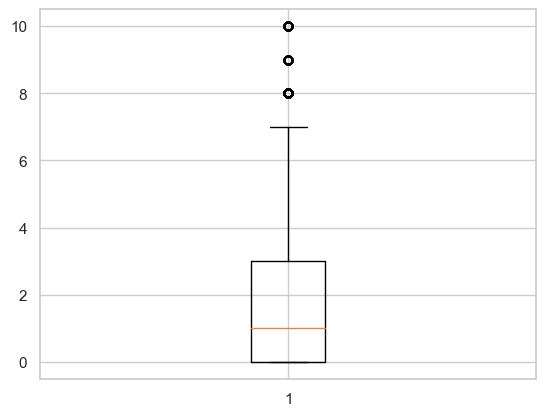

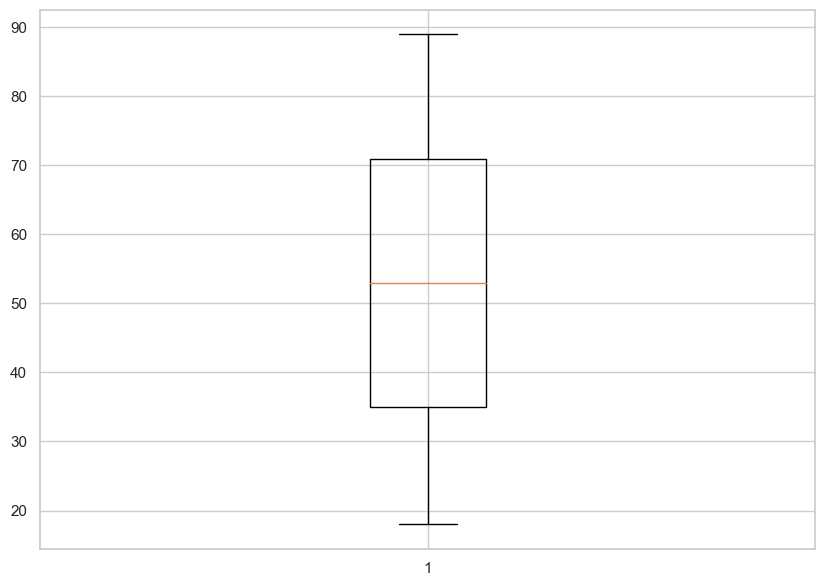

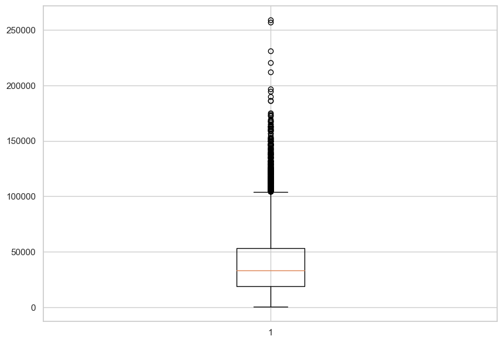

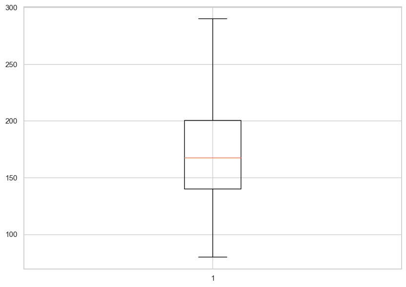

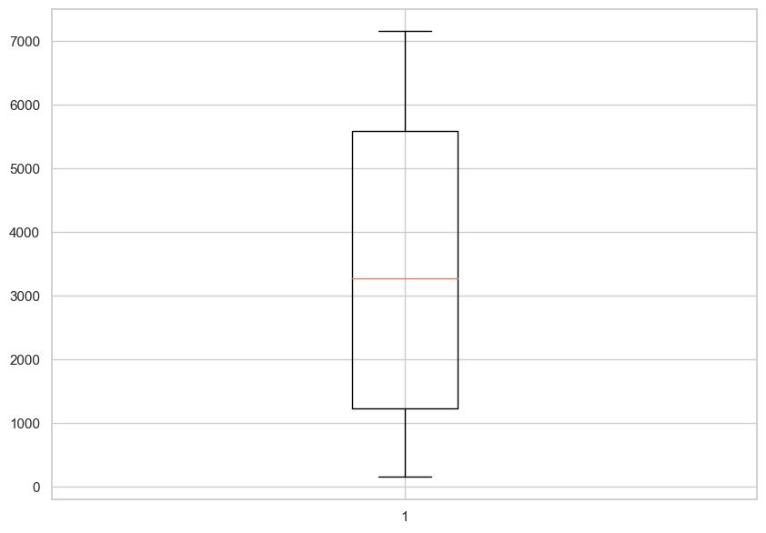

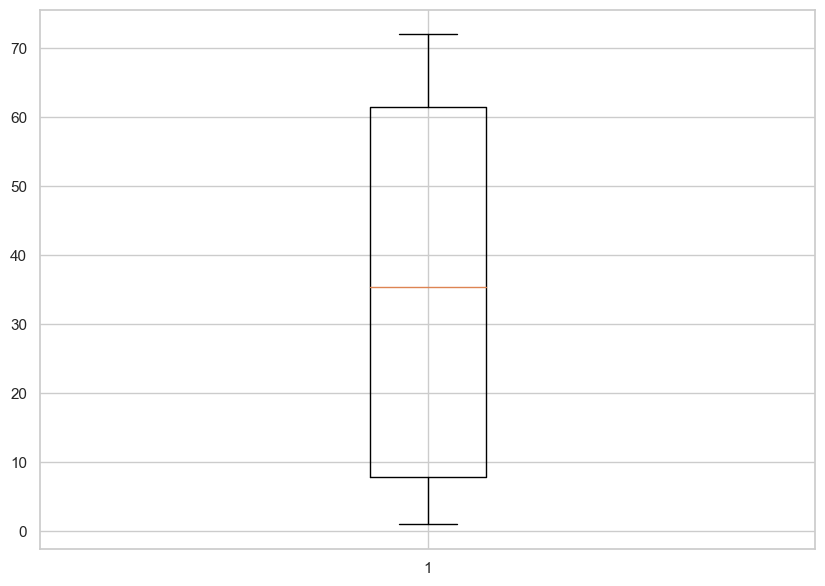

```python
for col in columns:
    # show outliers
    plt.boxplot(df[col])
    fig = plt.figure(figsize =(10, 7))
```

```python
# remove outliers in "Children"
df = df[df['Children'] < 8]
df.shape
```

```
(9599, 50)
```

```python
# drop unnecessary columns not used in the analysis
df = df[columns]
```

```python
# select rows that are duplicated based on all columns
dup = df[df.duplicated()]

# find out how many rows are duplicated
dup.shape
```

```
(0, 6)
```

```python
def show_missing(df):
    """
    Takes a dataframe and returns a dataframe with stats
    on missing and null values with their percentages.
    """
    null_count = df.isnull().sum()
    null_percentage = (null_count / df.shape[0]) * 100
    empty_count = pd.Series(((df == ' ') | (df == '')).sum())
    empty_percentage = (empty_count / df.shape[0]) * 100
    nan_count = pd.Series(((df == 'nan') | (df == 'NaN')).sum())
    nan_percentage = (nan_count / df.shape[0]) * 100
    dfx = pd.DataFrame({'num_missing': null_count, 'missing_percentage': null_percentage,
                         'num_empty': empty_count, 'empty_percentage': empty_percentage,
                         'nan_count': nan_count, 'nan_percentage': nan_percentage})
    return dfx

show_missing(df)
```

|  | num_missing | missing_percentage | num_empty | empty_percentage | nan_count | nan_percentage |
| --- | --- | --- | --- | --- | --- | --- |
| Children | 0 | 0.0 | 0 | 0.0 | 0 | 0.0 |
| Age | 0 | 0.0 | 0 | 0.0 | 0 | 0.0 |
| Income | 0 | 0.0 | 0 | 0.0 | 0 | 0.0 |
| MonthlyCharge | 0 | 0.0 | 0 | 0.0 | 0 | 0.0 |
| Bandwidth_GB_Year | 0 | 0.0 | 0 | 0.0 | 0 | 0.0 |
| Tenure | 0 | 0.0 | 0 | 0.0 | 0 | 0.0 |

```
array([[<Axes: title={'center': 'Children'}>,
        <Axes: title={'center': 'Age'}>],
       [<Axes: title={'center': 'Income'}>,
        <Axes: title={'center': 'MonthlyCharge'}>],
       [<Axes: title={'center': 'Bandwidth_GB_Year'}>,
        <Axes: title={'center': 'Tenure'}>]], dtype=object)
```

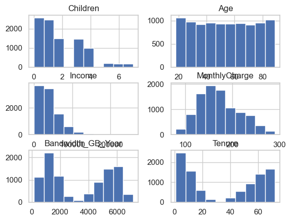

```python
# make historgrams and save the plot
df[columns].hist()
```

```python
df.head()
```

|  | Children | Age | Income | MonthlyCharge | Bandwidth_GB_Year | Tenure |
| --- | --- | --- | --- | --- | --- | --- |
| 0 | 0 | 68 | 28561.99 | 172.455519 | 904.536110 | 6.795513 |
| 1 | 1 | 27 | 21704.77 | 242.632554 | 800.982766 | 1.156681 |
| 2 | 4 | 50 | 9609.57 | 159.947583 | 2054.706961 | 15.754144 |
| 3 | 1 | 48 | 18925.23 | 119.956840 | 2164.579412 | 17.087227 |
| 4 | 0 | 83 | 40074.19 | 149.948316 | 271.493436 | 1.670972 |

```python
# scale the data
scaler = StandardScaler()

# apply scaler() to all the continuous column
scaled = pd.DataFrame(scaler.fit_transform(df), columns=df.columns)

scaled.head()
```

|  | Children | Age | Income | MonthlyCharge | Bandwidth_GB_Year | Tenure |
| --- | --- | --- | --- | --- | --- | --- |
| 0 | -1.071056 | 0.713714 | -0.398974 | -0.006432 | -1.135196 | -1.049171 |
| 1 | -0.479476 | -1.270369 | -0.642528 | 1.629571 | -1.182594 | -1.262376 |
| 2 | 1.295264 | -0.157347 | -1.072124 | -0.298023 | -0.608743 | -0.710444 |
| 3 | -0.479476 | -0.254131 | -0.741251 | -1.230307 | -0.558452 | -0.660040 |
| 4 | -1.071056 | 1.439598 | 0.009914 | -0.531131 | -1.424951 | -1.242931 |

```
array([[<Axes: title={'center': 'Children'}>,
        <Axes: title={'center': 'Age'}>],
       [<Axes: title={'center': 'Income'}>,
        <Axes: title={'center': 'MonthlyCharge'}>],
       [<Axes: title={'center': 'Bandwidth_GB_Year'}>,
        <Axes: title={'center': 'Tenure'}>]], dtype=object)
```

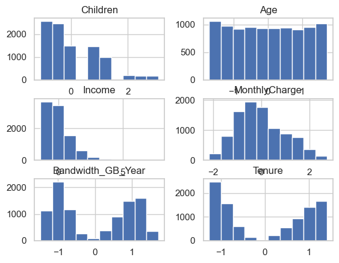

```python
# make historgrams and save the plot
scaled[columns].hist()
```

## C4. Provide a copy of the cleaned dataset.

```python
# save the prepared data set
scaled.to_csv('churn_prepared1.csv', index=False)
```

# Part IV - Analysis

## D1. Describe the analysis technique you used to appropriately analyze the data. Include screenshots of the intermediate calculations you performed.

The selected number of k clusters was two and scikit learn's implementation of k-means clustering was used to label each data point's cluster. The cluster labels were then assigned back to the unscaled dataframe and aggregated by mean, median, and standard deviation. Finally, the characteristics of each centroids were displayed and reviewed.

## D2. Provide the code used to perform the clustering technique from part D1.

```python
# determine the best value for k
inertia = np.array([])
k_vals = range(1,10)

for k in k_vals:
    kmeans = KMeans(n_clusters=k, random_state=493)
    kmeans.fit(scaled)
    inertia = np.append(inertia, kmeans.inertia_)

inertia_vals = pd.DataFrame(inertia, index=k_vals, columns=['Inertia'])
```

```
KMeans(n_clusters=1, random_state=493)
```

```
KMeans(n_clusters=2, random_state=493)
```

```
KMeans(n_clusters=3, random_state=493)
```

```
KMeans(n_clusters=4, random_state=493)
```

```
KMeans(n_clusters=5, random_state=493)
```

```
KMeans(n_clusters=6, random_state=493)
```

```
KMeans(n_clusters=7, random_state=493)
```

```
KMeans(random_state=493)
```

```
KMeans(n_clusters=9, random_state=493)
```

[output not shown]

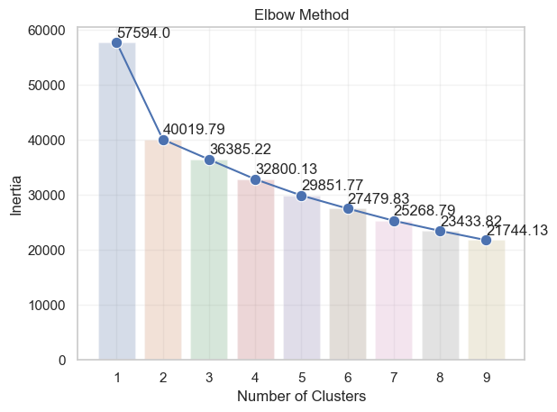

```python
# plot the inertia values
sns.barplot(x=inertia_vals.index, y=inertia_vals.Inertia, alpha=0.25)
sns.lineplot(x=inertia_vals.index-1, y=inertia_vals.Inertia, marker='o', markersize=9, legend=False)
plt.title('Elbow Method')
plt.xticks(inertia_vals.index-1)
plt.xlabel('Number of Clusters')
plt.ylabel('Inertia')
for i in inertia_vals.index:
    plt.text(
        x=i-1,
        y=inertia_vals.Inertia[i]+1000,
        s=round(inertia_vals.Inertia[i], 2)
    )
plt.grid(alpha=0.25)
```

```python
# do k-means clustering
n_clusters = 2
kmeans = KMeans(n_clusters=n_clusters, random_state=493)
kmeans.fit(scaled)
```

```
KMeans(n_clusters=2, random_state=493)
```

```python
# get predictions
predictions = kmeans.fit_predict(scaled)

# calculate the silhouette score
silhouette = silhouette_score(scaled, predictions)
print(f'Silhouette Score: {silhouette}, {n_clusters} clusters')
```

```
Silhouette Score: 0.29897803408788926, 2 clusters
```

```python
# assign cluster labels
df['Cluster'] = kmeans.labels_ + 1
```

```python
# calculate cluster summary
cluster = df.groupby('Cluster').agg(['mean', 'median', 'std']).transpose()
cluster.columns = ['Cluster 1', 'Cluster 2']
cluster
```

|  |  | Cluster 1 | Cluster 2 |
| --- | --- | --- | --- |
| Children | mean | 1.811446 | 1.809554 |
|  | median | 1.000000 | 1.000000 |
|  | std | 1.696421 | 1.684673 |
| Age | mean | 53.695109 | 52.806842 |
|  | median | 54.000000 | 53.000000 |
|  | std | 20.661250 | 20.662434 |
| Income | mean | 39974.132903 | 39615.565920 |
|  | median | 33056.020000 | 33348.015000 |
|  | std | 28456.884915 | 27853.631809 |
| MonthlyCharge | mean | 172.655381 | 172.807601 |
|  | median | 167.456400 | 169.937833 |
|  | std | 43.105339 | 42.692882 |
| Bandwidth_GB_Year | mean | 5463.462849 | 1301.088811 |
|  | median | 5574.461345 | 1224.665872 |
|  | std | 748.306325 | 568.844865 |
| Tenure | mean | 59.922603 | 9.106950 |
|  | median | 61.417660 | 7.890303 |
|  | std | 8.456071 | 6.028835 |

```python
# get the centroids
centroids = pd.DataFrame(
    scaler.inverse_transform(kmeans.cluster_centers_),
    index=['Cluster 1', 'Cluster 2'],
    columns=df.columns[:-1]
)
```

```python
# view the centroids
print('Cluster Centroids:\n')
for i in centroids.index:
    print(i)
    for col in centroids.columns:
        print(f'{col}: {round(centroids[col][i], 2)}')
    print()
```

```
Cluster Centroids:

Cluster 1
Children: 1.81
Age: 53.7
Income: 39974.13
MonthlyCharge: 172.66
Bandwidth_GB_Year: 5463.46
Tenure: 59.92

Cluster 2
Children: 1.81
Age: 52.81
Income: 39615.57
MonthlyCharge: 172.81
Bandwidth_GB_Year: 1301.09
Tenure: 9.11
```

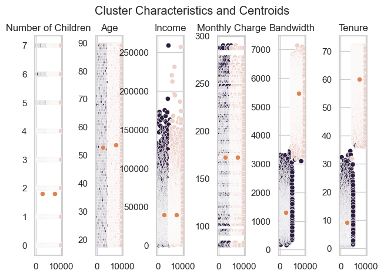

```python
# plot the centroids
centr_x = [sum(df[df.Cluster==1].index)/len(df[df.Cluster==1]),
           sum(df[df.Cluster==2].index)/len(df[df.Cluster==2])]

titles = [
    'Number of Children',
    'Age',
    'Income',
    'Monthly Charge',
    'Bandwidth',
    'Tenure',
]
y_labels = [
    '',
    '',
    '',
    '','',
    '',
]
fig, ax = plt.subplots(1, 6)
plt.suptitle('Cluster Characteristics and Centroids')
plt.rcParams['figure.figsize'] = (12,6)
plt.tight_layout()
for i in range(6):
    sns.scatterplot(x=df.index, y=df[df.columns[i]], hue=df.Cluster, ax=ax[i], legend=False)
    sns.scatterplot(x=centr_x, y=centroids[centroids.columns[i]], ax=ax[i])
    ax[i].set_title(titles[i])
    ax[i].set_ylabel(y_labels[i])
```

# Part V - Data Summary and Implications

## E1. Explain the accuracy of your clustering technique.

The final model with 2 clusters was evaluated using the silhoutte score. A silhoutte score is "a measure of how well each data point fits within its assigned cluster" (Castillo, 2023). The possible range of values for silhoutte score is from -1 to 1. A silhoutte score of 1 is the best, which indicates clearly defined clusters while -1 is the worst. A silhoutte score of near 0 indicates overlapping clusters (Banerji, 2021). In this case, the silhoutte score is 0.2989 which is near 0 so we can assume some overlap in our clusters.

## E2. Discuss the results and implications of your clustering analysis.

The twp most distinctive characteristics of the two clusters were the amount of bandwidth per year in gigabytes and tenure. Cluster 1's bandwidth is 5,463.46 GB while Cluster 2's bandwidth is only 1,301.09 GB. Respectively, Cluster 1's and Cluster 2's tenure were 59.92 and 9.11. Everything else, including the number of children, age, income, and monthly charge, were pretty much similar in values. This leads me to believe that customers with the longest tenure tend to be the heavy users of bandwidth as well.

The implication of this is the materialization of customer segments: heavy and light users of bandwidth.

## E3. Discuss one limitation of your data analysis.

One big limitation of this analysis is the exclusion of categorical variables because k-means clustering can only handle continuous variables. One categorical variable in mind is contract types. Previous analysis of the data set indicated that those customers with month-to-month contract types are more likely to churn than those with one and two-year contract types. As such, future analysis should utilize other clustering techniques that can deal with both continuous and categorical variables.

## E4. Recommend a course of action for the real-world organizational situation from part A1 based on your results and implications discussed in part E2.

An easy course of action for the organization is for the marketing department to make use of the newly discovered customer segments. For example, a marketing campaign can be designed to target light users of bandwidth and upsell them some streaming services. Bundling services is also an option. The point is that the more bandwidth a customer uses, the more likely that they are going to stick around.

# Part VI - Video Demonstration

## F. Panopto recording

URL: https://wgu.hosted.panopto.com/Panopto/Pages/Viewer.aspx?id=8fe99cc7-78d5-4f14-bcd2-b068006d2bfa

## G. Record the web sources used to acquire data or segments of third-party code to support the analysis. Ensure the web sources are reliable.

- https://github.com/ecdedios/code-snippets/blob/main/notebooks/master.ipynb
- https://www.analyticsvidhya.com/blog/2020/10/a-simple-explanation-of-k-means-clustering
- https://github.com/jlopez873/Telecom_Churn_Analysis_Using_Clustering_Techniques_Kmeans/blob/main/Clustering%20Techniques.ipynb

## H. Acknowledge sources, using in-text citations and references, for content that is quoted, paraphrased, or summarized.

- https://developers.google.com/machine-learning/clustering/algorithm/advantages-disadvantages
- https://stats.stackexchange.com/questions/576812/what-are-the-k-means-algorithm-assumptions
- https://javilopezcastillo.medium.com/telecom-churn-analysis-using-clustering-techniques-for-customer-segmentation-4cdb7318f672
- https://www.analyticsvidhya.com/blog/2021/05/k-mean-getting-the-optimal-number-of-clusters

```python
print('Successful run!')
```

```
Successful run!
```